# **Practical Machine Learning Course Project**

**Aayush Shah**

## **Introduction/Overview**

Using devices such as Jawbone Up, Nike FuelBand, and Fitbit it is now possible to collect a large amount of data about personal activity relatively inexpensively. These type of devices are part of the quantified self movement – a group of enthusiasts who take measurements about themselves regularly to improve their health, to find patterns in their behavior, or because they are tech geeks. One thing that people regularly do is quantify how much of a particular activity they do, but they rarely quantify how well they do it. In this project, your goal will be to use data from accelerometers on the belt, forearm, arm, and dumbell of 6 participants. They were asked to perform barbell lifts correctly and incorrectly in 5 different ways.

The data consists of training dataset and testing dataset (to be used to validate the selected model).

The goal of this project is to predict the manner in which they did the exercise. This is the *classe* variable in the training set.

But first, we load all the libraries.

```r
library(caret)
library(ggplot2)
library(rattle)
library(randomForest)
library(corrplot)
library(gbm)
```

## **Exploratory Data Analysis**

We get the data.

```r
filename1<-"pml-testing.csv"
filename2<-"pml-training.csv"
if (!file.exists(filename1)){
  url1<-"https://d396qusza40orc.cloudfront.net/predmachlearn/pml-training.csv"
  download.file(url1, filename1, method="curl")
}
if (!file.exists(filename2)){
  url2<-"https://d396qusza40orc.cloudfront.net/predmachlearn/pml-testing.csv"
  download.file(url2, filename2, method="curl")
}
```

Then we load and read the data.

```r
trainInput<-read.csv("pml-training.csv")
validationInput<-read.csv("pml-testing.csv")
```

Now we explore our data.

```r
dim(trainInput)
```

```
## [1] 19622   160
```

```r
dim(validationInput)
```

```
## [1]  20 160
```

```r
str(trainInput)
```

```
## 'data.frame':    19622 obs. of  160 variables:
##  $ X                       : int  1 2 3 4 5 6 7 8 9 10 ...
##  $ user_name               : Factor w/ 6 levels "adelmo","carlitos",..: 2 2 2 2 2 2 2 2 2 2 ...
##  $ raw_timestamp_part_1    : int  1323084231 1323084231 1323084231 1323084232 1323084232 1323084232 1323084232 1323084232 1323084232 1323084232 ...
##  $ raw_timestamp_part_2    : int  788290 808298 820366 120339 196328 304277 368296 440390 484323 484434 ...
##  $ cvtd_timestamp          : Factor w/ 20 levels "02/12/2011 13:32",..: 9 9 9 9 9 9 9 9 9 9 ...
##  $ new_window              : Factor w/ 2 levels "no","yes": 1 1 1 1 1 1 1 1 1 1 ...
##  $ num_window              : int  11 11 11 12 12 12 12 12 12 12 ...
##  $ roll_belt               : num  1.41 1.41 1.42 1.48 1.48 1.45 1.42 1.42 1.43 1.45 ...
##  $ pitch_belt              : num  8.07 8.07 8.07 8.05 8.07 8.06 8.09 8.13 8.16 8.17 ...
##  $ yaw_belt                : num  -94.4 -94.4 -94.4 -94.4 -94.4 -94.4 -94.4 -94.4 -94.4 -94.4 ...
##  $ total_accel_belt        : int  3 3 3 3 3 3 3 3 3 3 ...
##  $ kurtosis_roll_belt      : Factor w/ 397 levels "","-0.016850",..: 1 1 1 1 1 1 1 1 1 1 ...
##  $ kurtosis_picth_belt     : Factor w/ 317 levels "","-0.021887",..: 1 1 1 1 1 1 1 1 1 1 ...
##  $ kurtosis_yaw_belt       : Factor w/ 2 levels "","#DIV/0!": 1 1 1 1 1 1 1 1 1 1 ...
```

[output cut: 86 more lines]

So there 19622 observations of 160 variables in the *trainInput* dataset.

But on observation we find that there are lots of variables with missing values. So we remove them before proceeding.

```r
training<- trainInput[,colSums(is.na(trainInput)) == 0]
validation <- validationInput[,colSums(is.na(validationInput)) == 0]
str(training)
```

```
## 'data.frame':    19622 obs. of  93 variables:
##  $ X                      : int  1 2 3 4 5 6 7 8 9 10 ...
##  $ user_name              : Factor w/ 6 levels "adelmo","carlitos",..: 2 2 2 2 2 2 2 2 2 2 ...
##  $ raw_timestamp_part_1   : int  1323084231 1323084231 1323084231 1323084232 1323084232 1323084232 1323084232 1323084232 1323084232 1323084232 ...
##  $ raw_timestamp_part_2   : int  788290 808298 820366 120339 196328 304277 368296 440390 484323 484434 ...
##  $ cvtd_timestamp         : Factor w/ 20 levels "02/12/2011 13:32",..: 9 9 9 9 9 9 9 9 9 9 ...
##  $ new_window             : Factor w/ 2 levels "no","yes": 1 1 1 1 1 1 1 1 1 1 ...
##  $ num_window             : int  11 11 11 12 12 12 12 12 12 12 ...
##  $ roll_belt              : num  1.41 1.41 1.42 1.48 1.48 1.45 1.42 1.42 1.43 1.45 ...
##  $ pitch_belt             : num  8.07 8.07 8.07 8.05 8.07 8.06 8.09 8.13 8.16 8.17 ...
##  $ yaw_belt               : num  -94.4 -94.4 -94.4 -94.4 -94.4 -94.4 -94.4 -94.4 -94.4 -94.4 ...
##  $ total_accel_belt       : int  3 3 3 3 3 3 3 3 3 3 ...
##  $ kurtosis_roll_belt     : Factor w/ 397 levels "","-0.016850",..: 1 1 1 1 1 1 1 1 1 1 ...
##  $ kurtosis_picth_belt    : Factor w/ 317 levels "","-0.021887",..: 1 1 1 1 1 1 1 1 1 1 ...
##  $ kurtosis_yaw_belt      : Factor w/ 2 levels "","#DIV/0!": 1 1 1 1 1 1 1 1 1 1 ...
```

[output cut: 79 more lines]

```r
str(validation)
```

```
## 'data.frame':    20 obs. of  60 variables:
##  $ X                   : int  1 2 3 4 5 6 7 8 9 10 ...
##  $ user_name           : Factor w/ 6 levels "adelmo","carlitos",..: 6 5 5 1 4 5 5 5 2 3 ...
##  $ raw_timestamp_part_1: int  1323095002 1322673067 1322673075 1322832789 1322489635 1322673149 1322673128 1322673076 1323084240 1322837822 ...
##  $ raw_timestamp_part_2: int  868349 778725 342967 560311 814776 510661 766645 54671 916313 384285 ...
##  $ cvtd_timestamp      : Factor w/ 11 levels "02/12/2011 13:33",..: 5 10 10 1 6 11 11 10 3 2 ...
##  $ new_window          : Factor w/ 1 level "no": 1 1 1 1 1 1 1 1 1 1 ...
##  $ num_window          : int  74 431 439 194 235 504 485 440 323 664 ...
##  $ roll_belt           : num  123 1.02 0.87 125 1.35 -5.92 1.2 0.43 0.93 114 ...
##  $ pitch_belt          : num  27 4.87 1.82 -41.6 3.33 1.59 4.44 4.15 6.72 22.4 ...
##  $ yaw_belt            : num  -4.75 -88.9 -88.5 162 -88.6 -87.7 -87.3 -88.5 -93.7 -13.1 ...
##  $ total_accel_belt    : int  20 4 5 17 3 4 4 4 4 18 ...
##  $ gyros_belt_x        : num  -0.5 -0.06 0.05 0.11 0.03 0.1 -0.06 -0.18 0.1 0.14 ...
##  $ gyros_belt_y        : num  -0.02 -0.02 0.02 0.11 0.02 0.05 0 -0.02 0 0.11 ...
##  $ gyros_belt_z        : num  -0.46 -0.07 0.03 -0.16 0 -0.13 0 -0.03 -0.02 -0.16 ...
```

[output cut: 46 more lines]

So now the the *trainInput* dataset is reduced to *training* dataset with 19622 observations of 93 variables.

The first seven variables have little impact on *classe* variable. So we remove them too.

```r
training<-training[,-c(1:7)]
validation<-validation[,-c(1:7)]
```

## **Predictive Analysis**

Lets split the training dataset into 70% *trainData* and 30% *testData* datasets.(The *validation* dataset will be used later to test the prodiction algorithm on the 20 cases.)

```r
set.seed(1234)
inTrain<-createDataPartition(y=training$classe,p=0.7,list=FALSE)
trainData<-training[inTrain,]
testData<-training[-inTrain,]
```

On Observation, we see that lot of variable have near zero variance. So we remove them.

```r
NZV <- nearZeroVar(trainData)
trainData <- trainData[, -NZV]
testData  <- testData[, -NZV]
dim(trainData)
```

```
## [1] 13737    53
```

Lets keep the *testData* aside for some time.

Now the question is to find the correlation in the remaining variables except the *classe* variable. Lets do that visually.

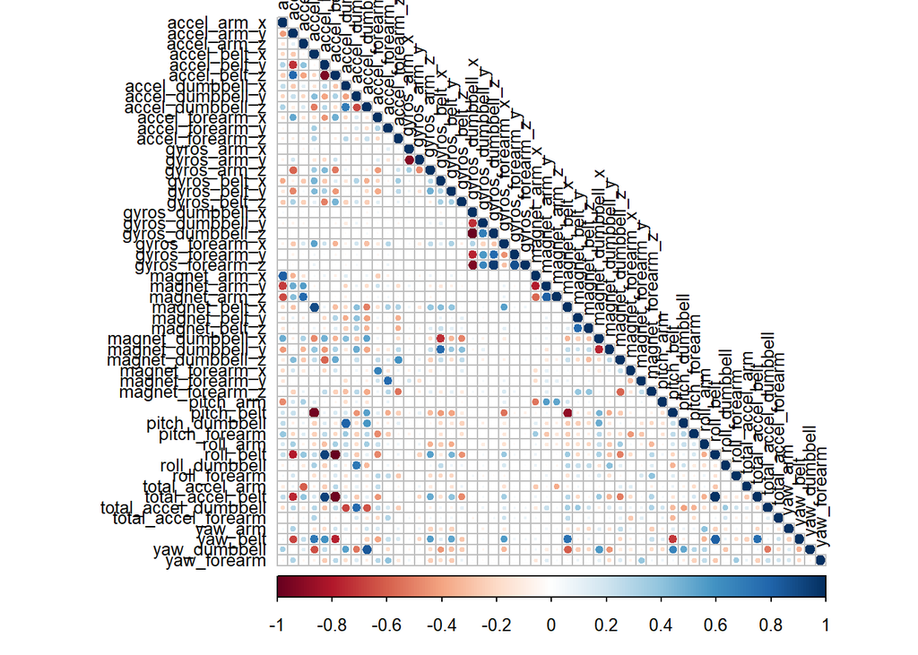

```r
cor_matrix <- cor(trainData[, -53])
corrplot(cor_matrix, order = "alphabet", method = "circle", type = "lower",tl.cex = 0.8, tl.col = rgb(0, 0, 0))
```

As we see, highly correlated variables have a darker colour intersection and bigger circles.

To get the names of these variables having correlation higher than 0.75 we do this;

```r
high_corr = findCorrelation(cor_matrix, cutoff=0.75)
names(trainData)[high_corr]
```

```
##  [1] "accel_belt_z"      "roll_belt"         "accel_belt_y"
##  [4] "total_accel_belt"  "accel_dumbbell_z"  "accel_belt_x"
##  [7] "pitch_belt"        "magnet_dumbbell_x" "accel_dumbbell_y"
## [10] "magnet_dumbbell_y" "accel_arm_x"       "accel_dumbbell_x"
## [13] "accel_arm_z"       "magnet_arm_y"      "magnet_belt_z"
## [16] "accel_forearm_y"   "gyros_forearm_y"   "gyros_dumbbell_x"
## [19] "gyros_dumbbell_z"  "gyros_arm_x"
```

Now lets build our models.

We will use the following methods to predict the *classe* variable;

1] Classification Trees

2] Random Forests

3] Generalized Boosted Models

### **Classification Trees**

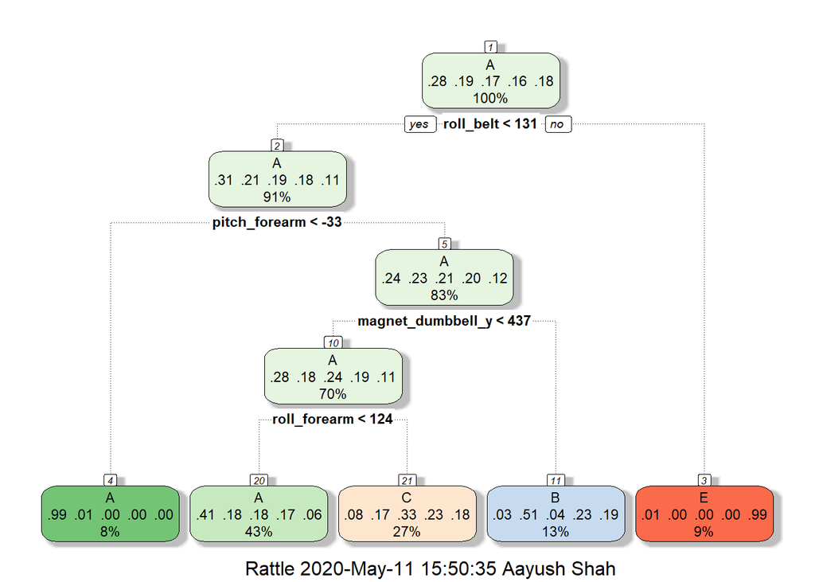

```r
trControl <- trainControl(method="cv", number=5)
model_CT <- train(classe~., data=trainData, method="rpart", trControl=trControl)
fancyRpartPlot(model_CT$finalModel)
```

Now we predict using the testData set.

```r
pred<-predict(model_CT,newdata=testData)
conf_mat<-confusionMatrix(testData$classe,pred)
conf_mat$table
```

```
##           Reference
## Prediction    A    B    C    D    E
##          A 1530   35  105    0    4
##          B  486  379  274    0    0
##          C  493   31  502    0    0
##          D  452  164  348    0    0
##          E  168  145  302    0  467
```

```r
conf_mat$overall[1]
```

```
##  Accuracy
## 0.4890399
```

We see that the accuracy is 0.4890399, which is very low. So *classe* is not well predicted by other variables in this model.

### **Random Forests**

```r
set.seed(1234)
trControl <- trainControl(method="cv", number=3, verboseIter=FALSE)
modRF1 <- train(classe ~ ., data=trainData, method="rf", trControl=trControl)
```

```r
print(modRF1)
```

```
## Random Forest
##
## 13737 samples
##    52 predictor
##     5 classes: 'A', 'B', 'C', 'D', 'E'
##
## No pre-processing
## Resampling: Cross-Validated (3 fold)
## Summary of sample sizes: 9157, 9160, 9157
## Resampling results across tuning parameters:
##
##   mtry  Accuracy   Kappa
##    2    0.9892261  0.9863699
##   27    0.9903179  0.9877511
##   52    0.9856590  0.9818569
##
## Accuracy was used to select the optimal model using the largest value.
## The final value used for the model was mtry = 27.
```

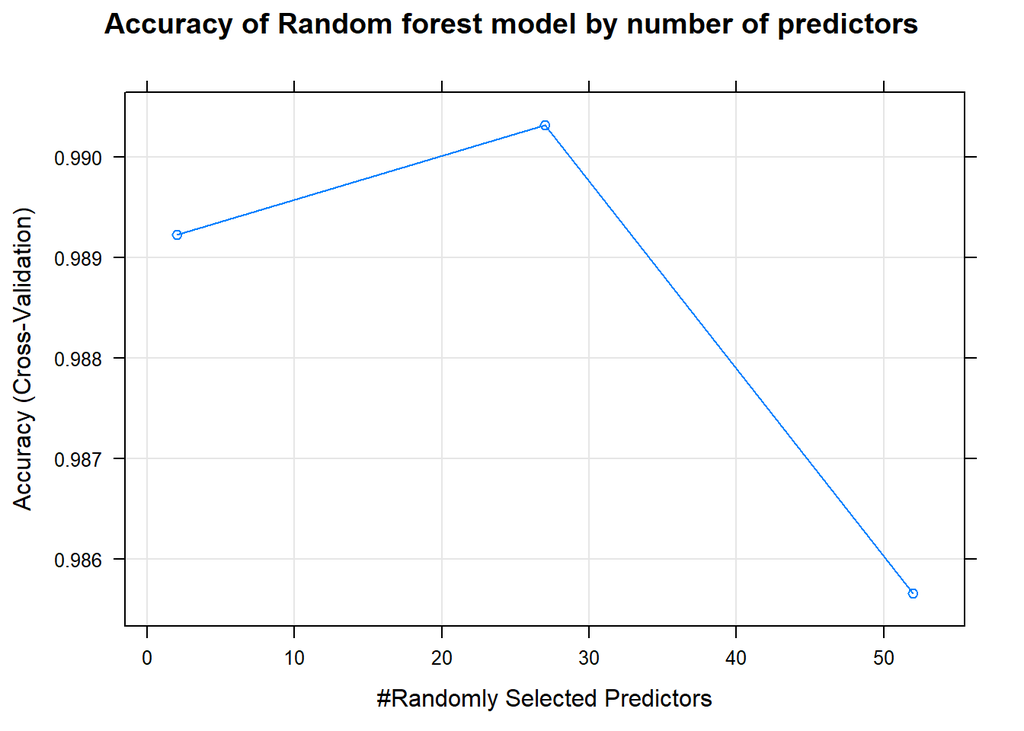

```r
plot(modRF1,main="Accuracy of Random forest model by number of predictors")
```

Now we predict using the testData set.

```r
pred2<-predict(modRF1,newdata=testData)
conf_mat2<-confusionMatrix(testData$classe,pred2)
conf_mat2$table
```

```
##           Reference
## Prediction    A    B    C    D    E
##          A 1674    0    0    0    0
##          B   10 1128    1    0    0
##          C    0    4 1018    4    0
##          D    0    1    5  957    1
##          E    0    1    2    3 1076
```

```r
conf_mat2$overall[1]
```

```
##  Accuracy
## 0.9945624
```

We see that the accuracy is 0.9945624, which is very high. So *classe* is very well predicted by other variables in this model.

This is very good. But let’s see what we can expect with Gradient boosting.

### **Gradient Boosting Method**

```r
model_GBM <- train(classe~., data=trainData, method="gbm", trControl=trControl, verbose=FALSE)
print(model_GBM)
```

```
## Stochastic Gradient Boosting
##
## 13737 samples
##    52 predictor
##     5 classes: 'A', 'B', 'C', 'D', 'E'
##
## No pre-processing
## Resampling: Cross-Validated (3 fold)
## Summary of sample sizes: 9157, 9158, 9159
## Resampling results across tuning parameters:
##
##   interaction.depth  n.trees  Accuracy   Kappa
##   1                   50      0.7489270  0.6817765
##   1                  100      0.8169916  0.7683562
##   1                  150      0.8502593  0.8105405
##   2                   50      0.8525156  0.8132028
##   2                  100      0.9034719  0.8778487
##   2                  150      0.9298245  0.9111776
##   3                   50      0.8937904  0.8655021
##   3                  100      0.9387784  0.9225157
##   3                  150      0.9584335  0.9474034
##
## Tuning parameter 'shrinkage' was held constant at a value of 0.1
##
## Tuning parameter 'n.minobsinnode' was held constant at a value of 10
## Accuracy was used to select the optimal model using the largest value.
## The final values used for the model were n.trees = 150, interaction.depth =
##  3, shrinkage = 0.1 and n.minobsinnode = 10.
```

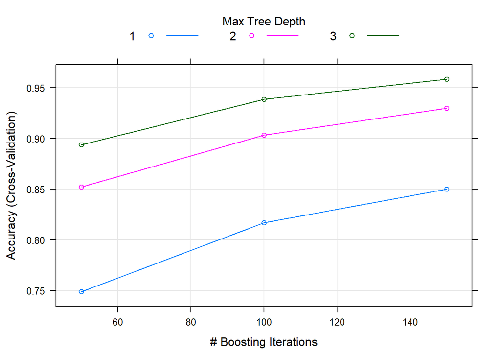

```r
plot(model_GBM)
```

Now we predict using testData

```r
pred3<-predict(model_GBM,newdata=testData)
conf_mat3<-confusionMatrix(testData$classe,pred3)
conf_mat3$table
```

```
##           Reference
## Prediction    A    B    C    D    E
##          A 1652   13    2    6    1
##          B   46 1065   24    3    1
##          C    0   32  980   11    3
##          D    0    4   17  936    7
##          E    1    9   15   15 1042
```

```r
conf_mat3$overall[1]
```

```
##  Accuracy
## 0.9643161
```

So the accuracy is 0.9643161

## **Predicting the validation data with the best model**

On comparison, the accuracy of the Random Forest model is the highest. So will use it on the *validation* dataset.

```r
result<-predict(modRF1,newdata=validation)
result
```

```
##  [1] B A B A A E D B A A B C B A E E A B B B
## Levels: A B C D E
```

This *result* will be used to answer the quiz for the course.